# Histograms

Companion `R` Code for Stats 101 Video Lesson

Created by Jill E. Thomley

Saturday, February 26, 2022 @ 04:36 PM

▶ [GO TO VIDEO](https://youtu.be/zC3GaPBJ4c4)

## Packages Used

```r
library(tidyverse)
```

## Correction to the Video

There is one error in the video that you need to keep in mind as you work with data. In addition to the bins of the histogram not overlapping, a standard histogram also generally needs to have bins of the same width. Variable width bins is a different kind of plot (e.g., an equal probability histogram) that needs to have a specific rationale.

## Smartphone User Example

### Read in the Dataset

The data is in a CSV file stored on the web, so we will read it into RStudio using `read_csv()` from the tidyverse package (which has been loaded above). It is always good to inspect the structure of a dataset, especially if you have not used it before.

```r
URL <- "https://raw.githubusercontent.com/STAT-JET-ASU/Datasets/master/Stats101/stats101smartphones.csv"
smartphones <- read_csv(URL)
glimpse(smartphones)
```

```
Rows: 100
Columns: 2
$ brand <chr> "Apple", "LG", "Apple", "Samsung", "Apple", "Other", "Apple", "L…
$ age   <dbl> 58, 22, 28, 68, 39, 44, 26, 27, 25, 66, 23, 54, 48, 31, 50, 41, …
```

```r
head(smartphones)
```

```
# A tibble: 6 × 2
  brand     age
  <chr>   <dbl>
1 Apple      58
2 LG         22
3 Apple      28
4 Samsung    68
5 Apple      39
6 Other      44
```

### Making Histograms

#### Default Histogram

The default setting for `bins` in `geom_histogram()` is 30. Too many! `R` also gives you a message.

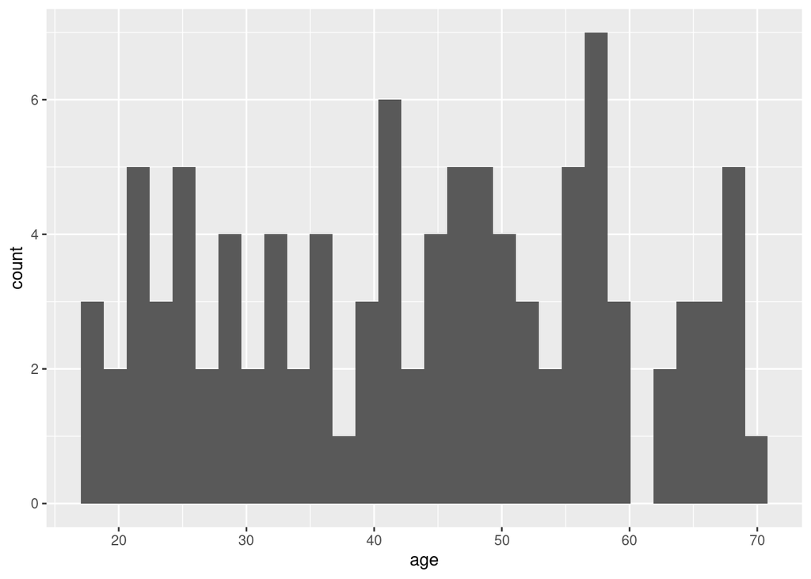

```r
ggplot(smartphones, aes(x = age)) +
  geom_histogram()
```

#### Histogram with One Bin

Here is the “histoblob” mentioned in the video. The maximum age value in the dataset is 70, so that is the upper end of the plot in `R`. Differences from the video are due to the software used and the flexible nature of histograms.

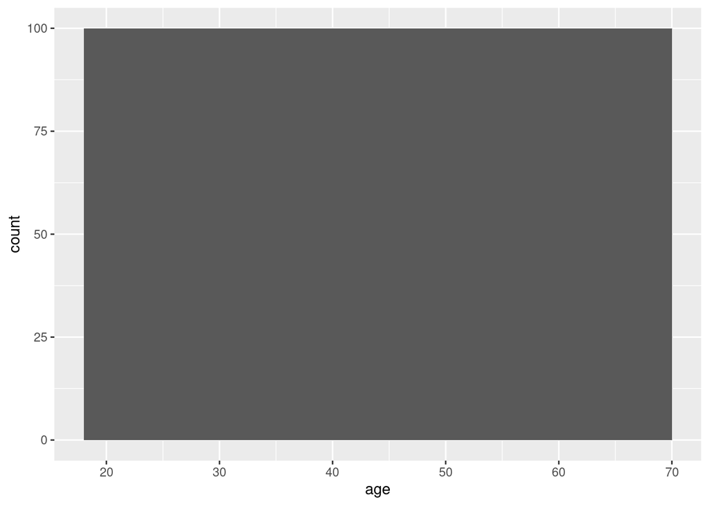

```r
ggplot(smartphones, aes(x = age)) +
  geom_histogram(bins = 1)
```

#### Histogram with Three Bins

The bins and the histogram in the video are slightly incorrect because the leftmost bin is not the same size (width on the number line) as the others. We can specify bins multiple ways. The color and axis scaling help us visualize better where bins start and stop. Notice that different methods give us different plots.

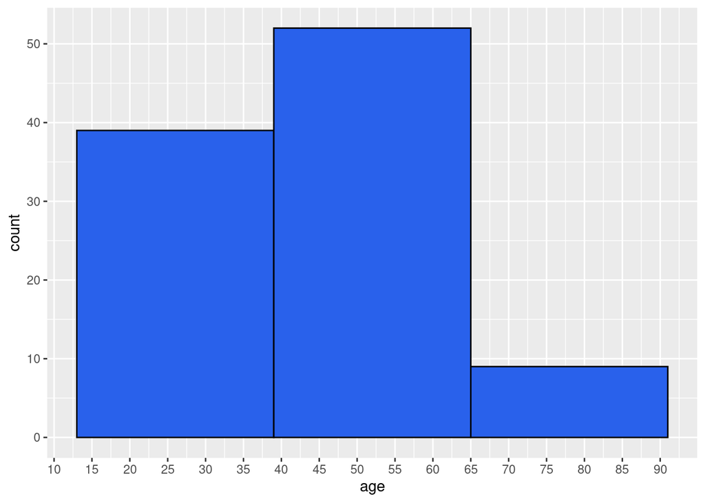

```r
# specify using number of bins

ggplot(smartphones, aes(x = age)) +
  geom_histogram(color = "black", fill = "#2961EB", bins = 3) +
  scale_x_continuous(breaks = seq(from = 0, to = 100, by = 5))
```

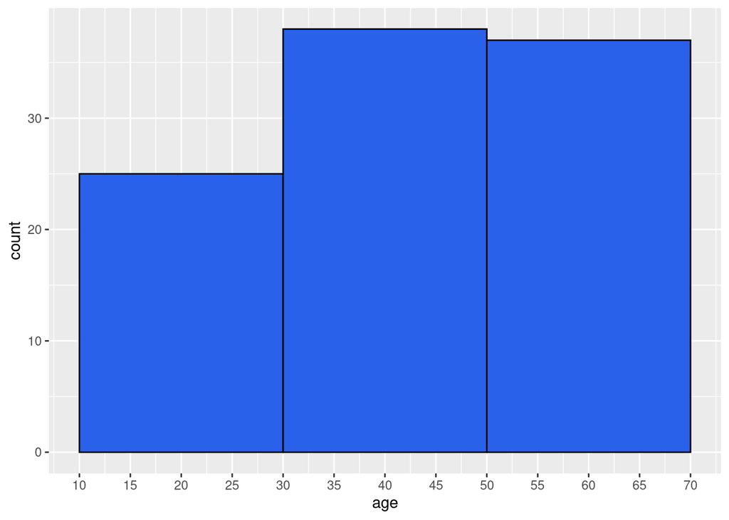

```r
# specify using width of bins

ggplot(smartphones, aes(x = age)) +
  geom_histogram(color = "black", fill = "#2961EB", binwidth = 20) +
  scale_x_continuous(breaks = seq(0, 100, 5)) # we can abbreviate the seq code
```

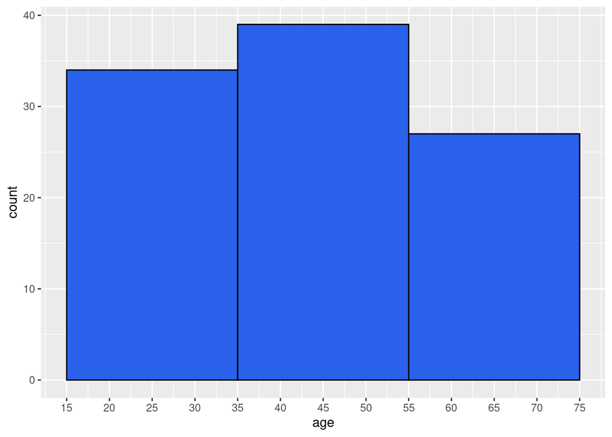

```r
# specify using boundaries of bins
# this is good for comparing plots
# the intervals are (lower, upper]
# aka, lower < age value <= upper
# reverse this using closed = left

ggplot(smartphones, aes(x = age)) +
  geom_histogram(color = "black", fill = "#2961EB", breaks = seq(15, 75, 20)) +
  scale_x_continuous(breaks = seq(0, 100, 5))
```

#### Histogram with Six Bins

The bins and the histogram in the video are slightly incorrect because the leftmost bin is not the same size (width on the number line) as the others. We can specify bins multiple ways. The color and axis scaling help us visualize better where bins start and stop. Notice that different methods give us different plots.

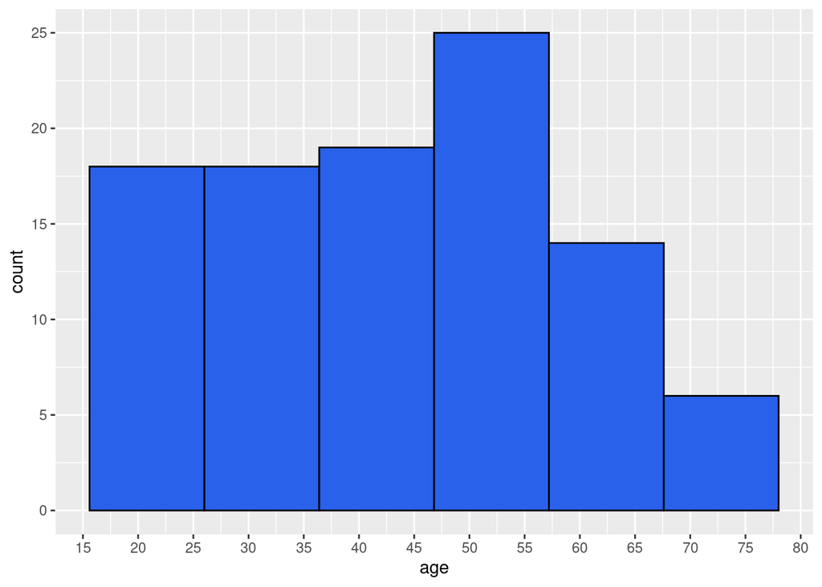

```r
# specify using number of bins

ggplot(smartphones, aes(x = age)) +
  geom_histogram(color = "black", fill = "#2961EB", bins = 6) +
  scale_x_continuous(breaks = seq(0, 100, 5))
```

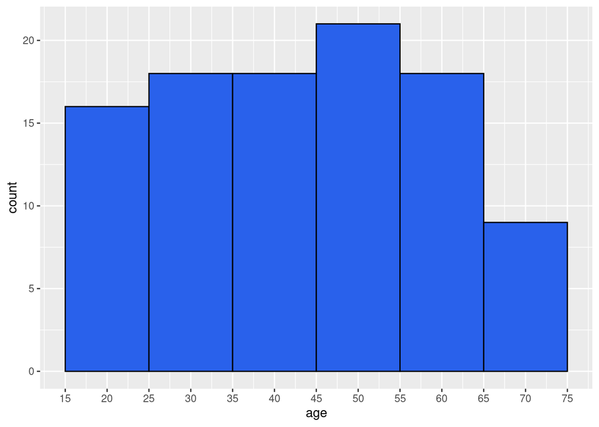

```r
# specify using width of bins

ggplot(smartphones, aes(x = age)) +
  geom_histogram(color = "black", fill = "#2961EB", binwidth = 10) +
  scale_x_continuous(breaks = seq(0, 100, 5))
```

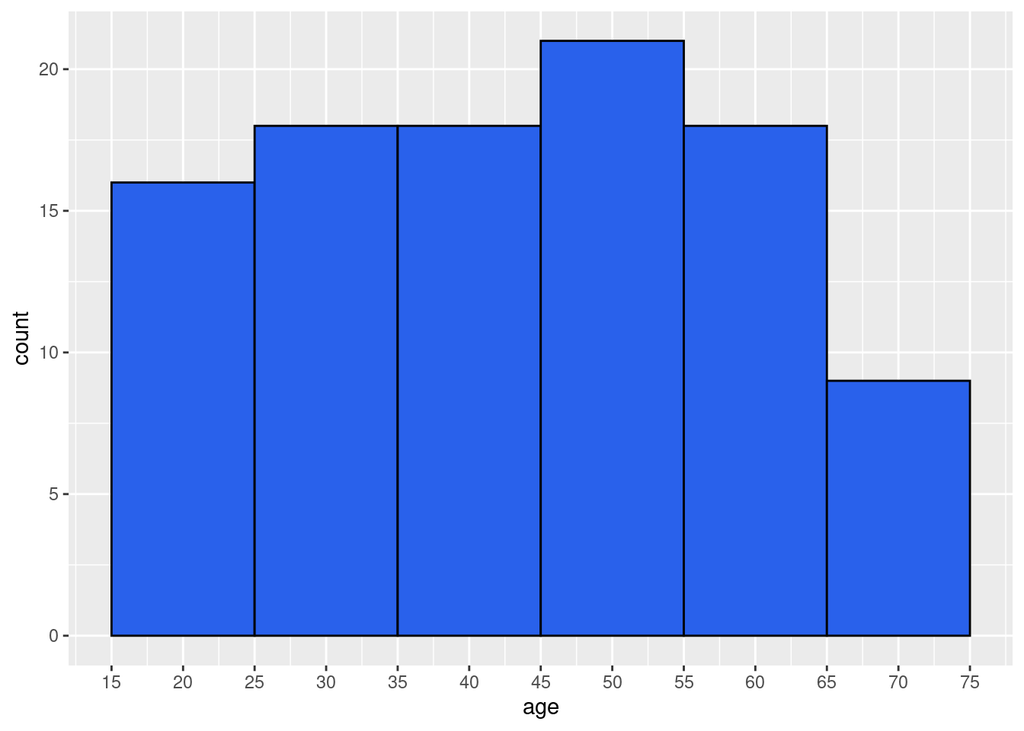

```r
# specify using boundaries of bins
# this is good for comparing plots
# the intervals are (lower, upper]
# aka, lower < age value <= upper
# reverse this using closed = left

ggplot(smartphones, aes(x = age)) +
  geom_histogram(color = "black", fill = "#2961EB", breaks = seq(15, 75, 10)) +
  scale_x_continuous(breaks = seq(0, 100, 5))
```

#### Histogram with Twelve Bins

The bins and the histogram in the video are slightly incorrect because the leftmost bin is not the same size (width on the number line) as the others. We can specify bins multiple ways. The color and axis scaling help us visualize better where bins start and stop. Notice that different methods give us different plots.

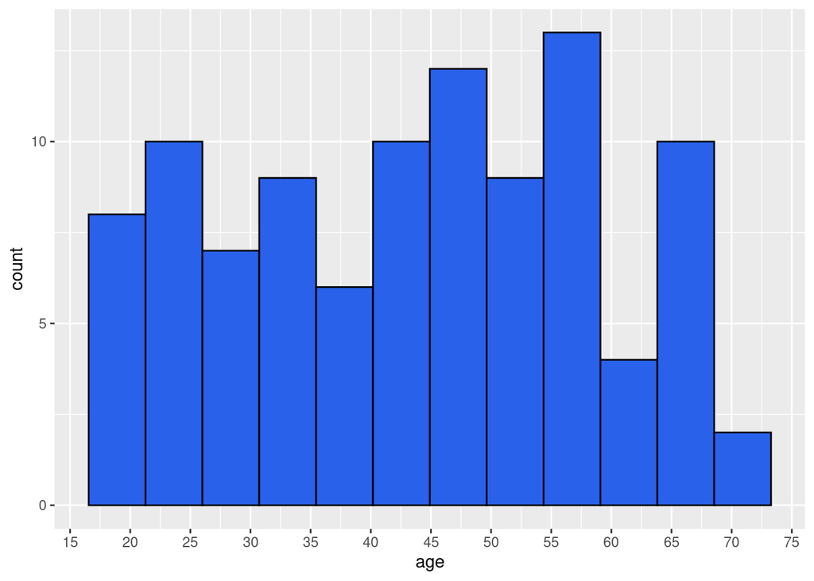

```r
# specify using number of bins

ggplot(smartphones, aes(x = age)) +
  geom_histogram(color = "black", fill = "#2961EB", bins = 12) +
  scale_x_continuous(breaks = seq(0, 100, 5))
```

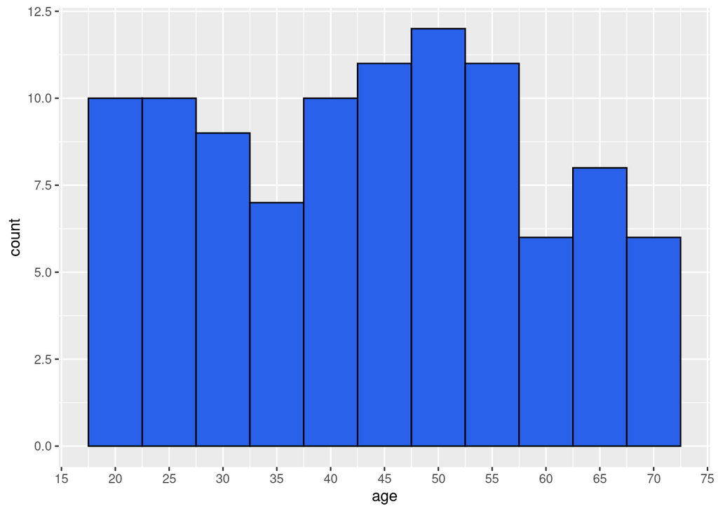

```r
# specify using width of bins

ggplot(smartphones, aes(x = age)) +
  geom_histogram(color = "black", fill = "#2961EB", binwidth = 5) +
  scale_x_continuous(breaks = seq(0, 100, 5))
```

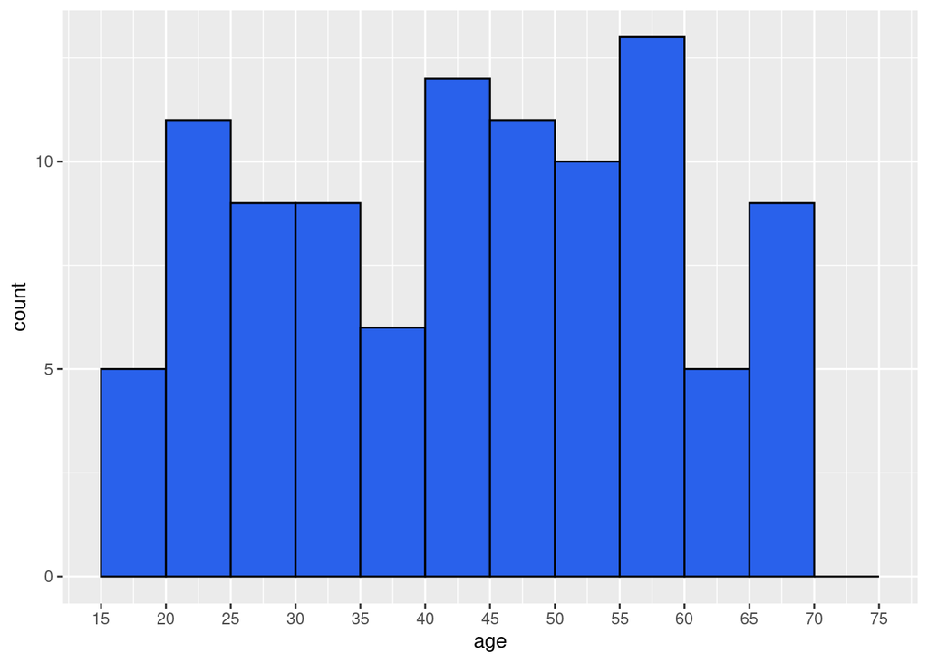

```r
# specify using boundaries of bins
# this is good for comparing plots
# the intervals are (lower, upper]
# aka, lower < age value <= upper
# reverse this using closed = left

ggplot(smartphones, aes(x = age)) +
  geom_histogram(color = "black", fill = "#2961EB", breaks = seq(15, 75, 5)) +
  scale_x_continuous(breaks = seq(0, 100, 5))
```

### Frequency Polygons

A frequency polygon is an alternative to a histogram. It also uses bins to count data frequencies; however, rather than drawing a bar for each bin, the polygon connects the midpoints of the histogram bars with a line.

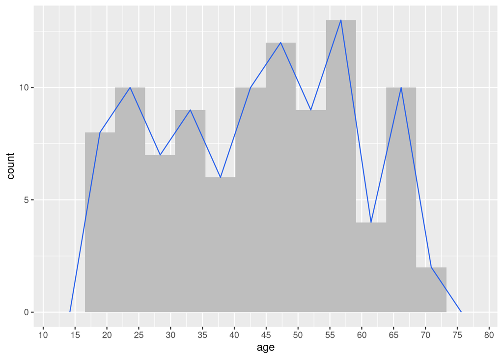

```r
ggplot(smartphones, aes(x = age)) +
  geom_histogram(fill = "gray", bins = 12) +
  geom_freqpoly(color = "#2961EB", bins = 12) +
  scale_x_continuous(breaks = seq(0, 100, 5))
```

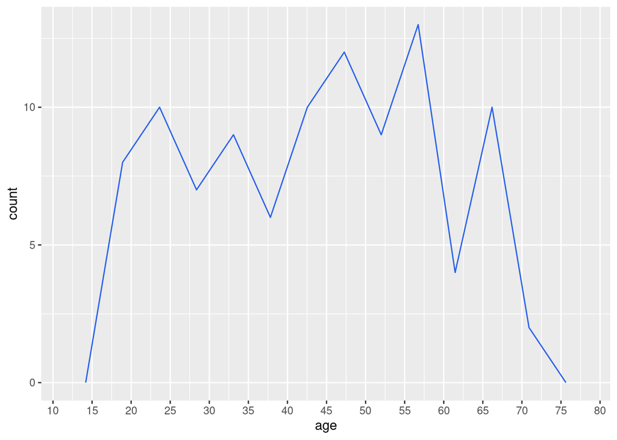

```r
ggplot(smartphones, aes(x = age)) +
  geom_freqpoly(color = "#2961EB", bins = 12) +
  scale_x_continuous(breaks = seq(0, 100, 5))
```

### Density Plots

A density plot smooths a frequency polygon (using a weighted moving average) to estimate a continuous curve from discrete data. The area under the density curve is always 1. We can rescale a histogram or polygon to match using `aes(y = ..density..)`.

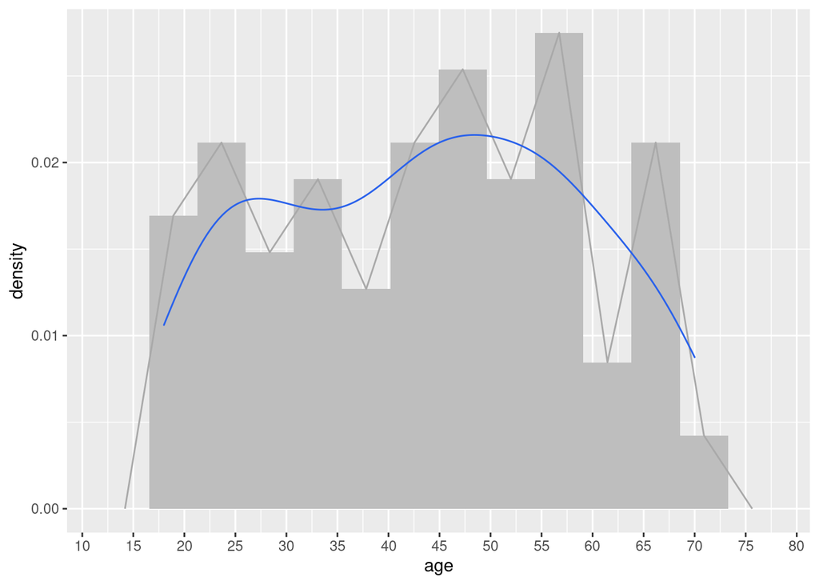

```r
ggplot(smartphones, aes(x = age)) +
  geom_histogram(aes(y = ..density..), fill = "gray", bins = 12) +
  geom_freqpoly(aes(y = ..density..), color = "darkgray", bins = 12) +
  geom_density(color = "#2961EB") +
  scale_x_continuous(breaks = seq(0, 100, 5))
```

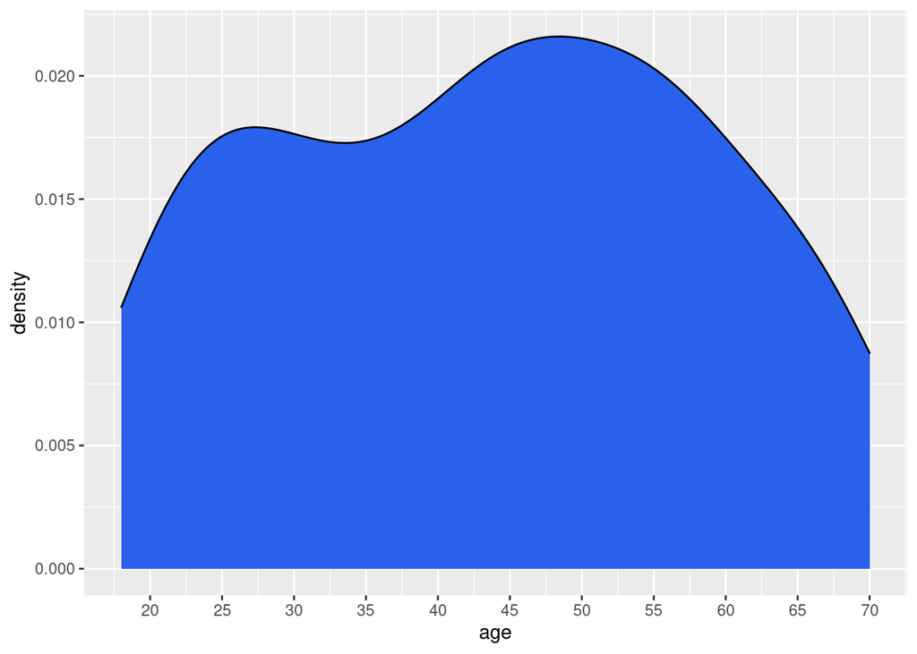

```r
ggplot(smartphones, aes(x = age)) +
  geom_density(color = "black", fill = "#2961EB") +
  scale_x_continuous(breaks = seq(0, 100, 5))
```

### Adding Better Labels

For presentation, add a title and better x- and y-axis labels. Include units for quantitative data.

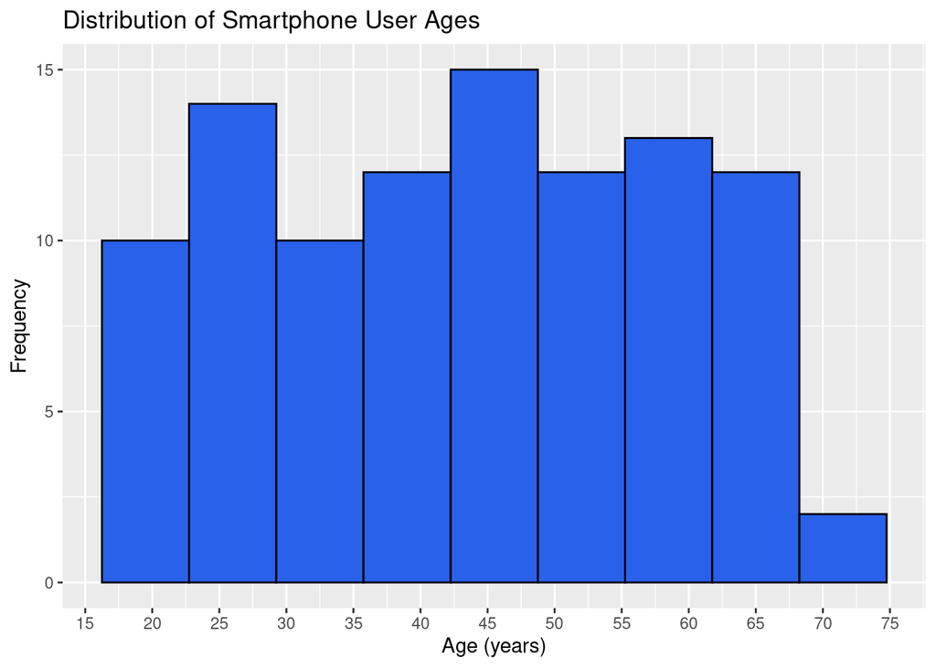

```r
ggplot(smartphones, aes(x = age)) +
  geom_histogram(
    color = "black",
    fill = "#2961EB",
    bins = 9
  ) +
  scale_x_continuous(breaks = seq(0, 100, 5)) +
  labs(
    title = "Distribution of Smartphone User Ages",
    x = "Age (years)",
    y = "Frequency"
  )
```

### References

Tidyverse: [Histograms and Frequency Polygons](https://ggplot2.tidyverse.org/reference/geom_histogram.html)

Tidyverse: [Smoothed Density Estimates](https://ggplot2.tidyverse.org/reference/geom_density.html)